# ECON90033 - S2 2023 - Assignment 2

Josh Copeland (SID: 1444772)

Tutorial class: Thursday 16:15

Generated on October 02, 2023

# Exercise 1

## a) Launch RStudio, create a new project and script, and name both a2e1. Import the data from the a2e1.xlsx file to RStudio, save it as a2e1.RData, and attach this data set to your R project. Create an xts objects of the DJ series.

## Plot the Dow Jones index and its percentage log returns (r) and comment on any volatility clustering.

## Once charted, remove NA values from the series and use this series for all subsequent questions. (2 marks)

There are three major periods, or clusters, of volatility in the chart shown below for the returns of the Dow Jones Industrial Index:

- There was a period of sustained, moderate volatility in returns at the beginning of the time series from around 2000 to around 2003. This is likely due to the effects of the dotcom bubble of that period.
- There is a period of more intense volatility around 2008, likely due to the effects of the Global Financial Crisis.
- There is also another period of significant volatility in 2020, likely due to the COVID-19 outbreak.

There are other periods of less intense volatility through the 2010s, likely in part driven by different periods of the European Sovereign Debt Crises, but these are not as significant as those listed above.

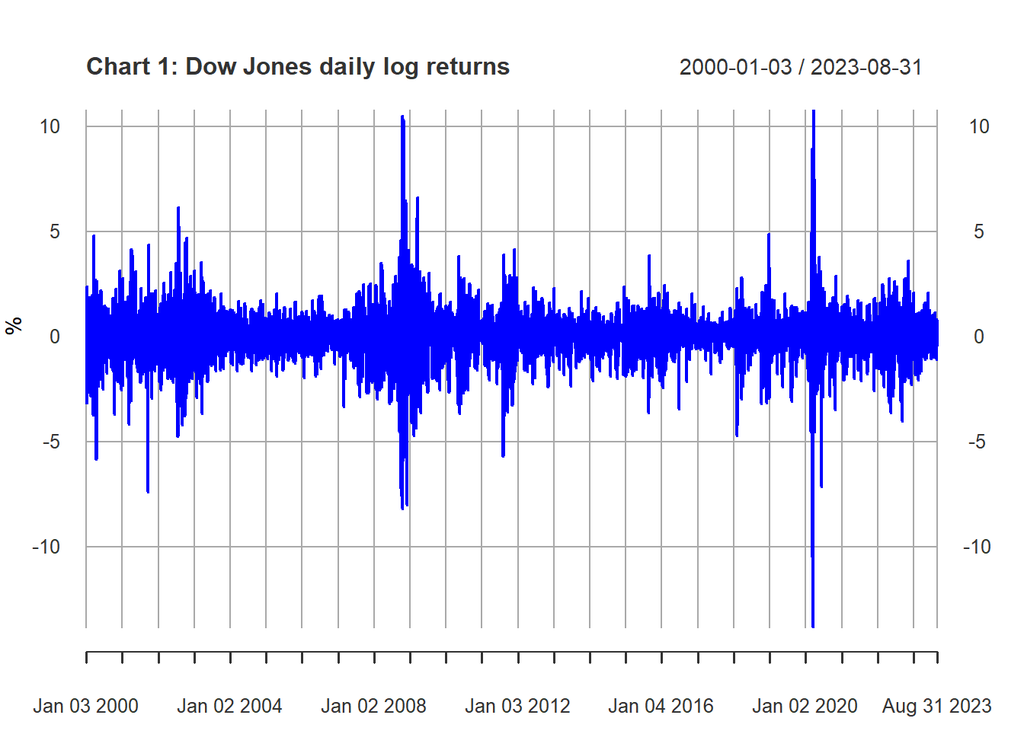

```r
DJ <- read_excel("C:/Users/joshc/Documents/2023S2/ECON90033/Assignments/Assignment 2/a2e1.xlsx")

date <- DJ %>%
  pull(Date)

DJ <- DJ %>%
  pull(DJ) %>%
  xts(order.by = date)

r <- diff(log(DJ)) * 100


plot(r, main = "Chart 1: Dow Jones daily log returns", ylab = "%", col = "blue")
```

```r
r <- na.omit(r)
```

## b) Perform the ADF and KPSS tests on r. What conclusion do you draw from these tests about the order of integration of the percentage log returns of the Dow Jones Industrial Index? (4 marks)

The code below shows the results of the Augmented Dicky Fuller (ADF) and Kwiatkowski–Phillips–Schmidt–Shin (KPSS) tests on the daily returns of the Dow Jones industrial index, as well as the difference of this series. We need to provide tests for two levels of differencing as these tests are only able to detect a single unit root. Without testing for the differenced series as well, we might incorrectly assume there are no unit roots when there are actually two.

As daily log returns and its differenced series both fluctuate around zero (Chart 1 and Chart 2), we use “Model 1” when developing the ADF and KPSS models. Practically, this means we set the “type” parameter to “none” and “mu” for the ADF and KPSS tests respectively.

Taking all of these test results together we come to the following conclusion:

```r
#ADF tests

r_ADF <- ur.df(r, type = "none", selectlags = "BIC")

summary(r_ADF)
```

```
##
## ###############################################
## # Augmented Dickey-Fuller Test Unit Root Test #
## ###############################################
##
## Test regression none
##
##
## Call:
## lm(formula = z.diff ~ z.lag.1 - 1 + z.diff.lag)
##
## Residuals:
##      Min       1Q   Median       3Q      Max
## -12.9328  -0.4691   0.0663   0.5637  10.4406
##
## Coefficients:
##             Estimate Std. Error t value Pr(>|t|)
## z.lag.1    -1.104355   0.019253 -57.361   <2e-16 ***
## z.diff.lag  0.001284   0.012957   0.099    0.921
## ---
## Signif. codes:  0 '***' 0.001 '**' 0.01 '*' 0.05 '.' 0.1 ' ' 1
##
## Residual standard error: 1.177 on 5949 degrees of freedom
## Multiple R-squared:  0.5515, Adjusted R-squared:  0.5514
## F-statistic:  3658 on 2 and 5949 DF,  p-value: < 2.2e-16
##
##
## Value of test-statistic is: -57.3606
##
## Critical values for test statistics:
##       1pct  5pct 10pct
## tau1 -2.58 -1.95 -1.62
```

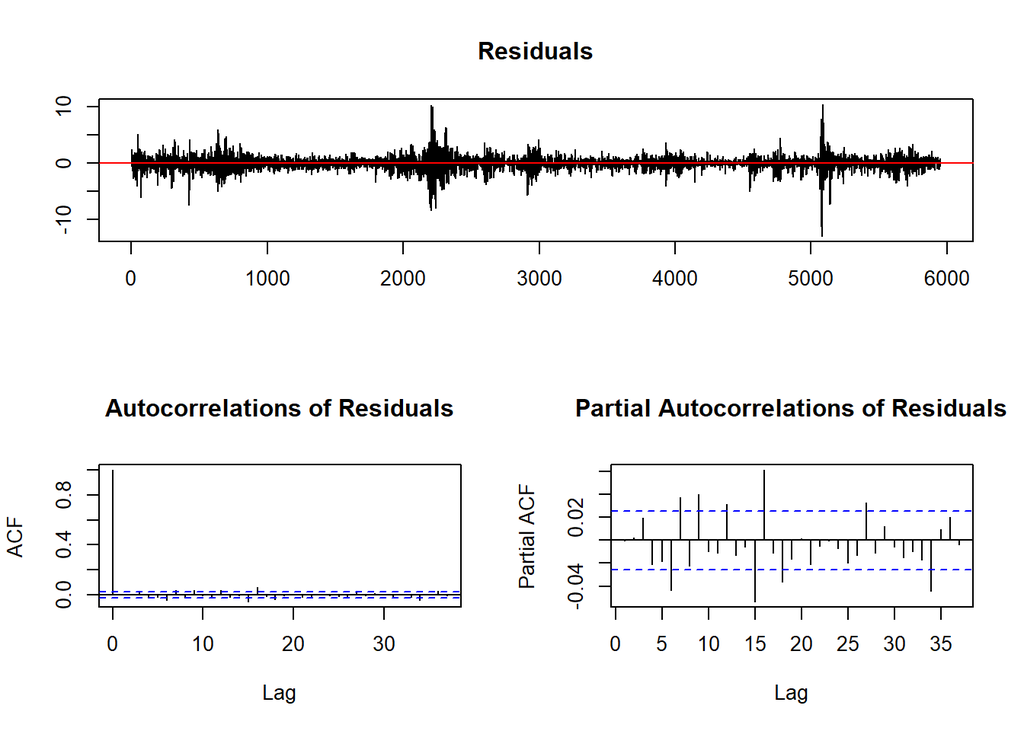

```r
plot(r_ADF)
```

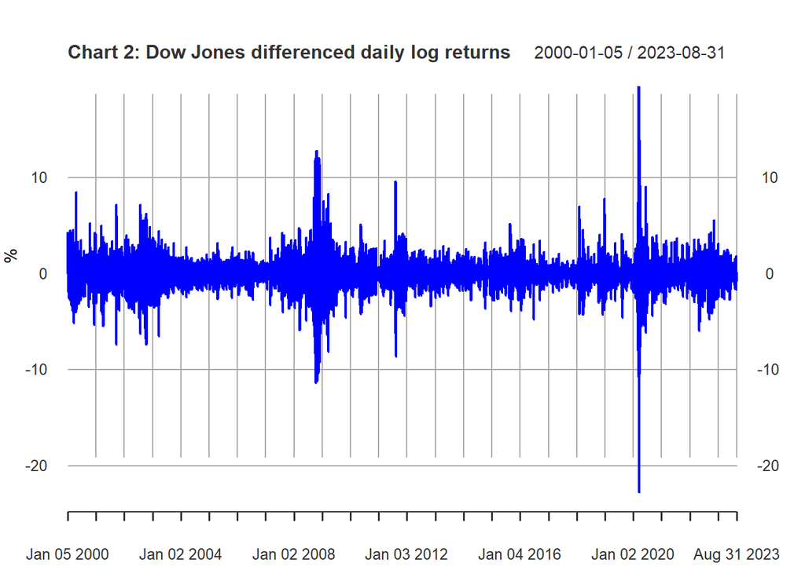

```r
r_diff <- diff(r) %>%
  na.omit()

plot(r_diff, main = "Chart 2: Dow Jones differenced daily log returns", ylab = "%", col = "blue")
```

```r
r_diff_ADF <- ur.df(r_diff, type = "none", selectlags = "BIC")

summary(r_diff_ADF)
```

```
##
## ###############################################
## # Augmented Dickey-Fuller Test Unit Root Test #
## ###############################################
##
## Test regression none
##
##
## Call:
## lm(formula = z.diff ~ z.lag.1 - 1 + z.diff.lag)
##
## Residuals:
##      Min       1Q   Median       3Q      Max
## -11.4957  -0.6550  -0.0467   0.6325  14.5592
##
## Coefficients:
##            Estimate Std. Error t value Pr(>|t|)
## z.lag.1    -2.12363    0.02121 -100.11   <2e-16 ***
## z.diff.lag  0.36906    0.01204   30.65   <2e-16 ***
## ---
## Signif. codes:  0 '***' 0.001 '**' 0.01 '*' 0.05 '.' 0.1 ' ' 1
##
## Residual standard error: 1.363 on 5948 degrees of freedom
## Multiple R-squared:  0.8062, Adjusted R-squared:  0.8061
## F-statistic: 1.237e+04 on 2 and 5948 DF,  p-value: < 2.2e-16
##
##
## Value of test-statistic is: -100.1132
##
## Critical values for test statistics:
##       1pct  5pct 10pct
## tau1 -2.58 -1.95 -1.62
```

```r
#KPSS tests

r_KPSS <- ur.kpss(r, type = "mu", lags = "long")

summary(r_KPSS)
```

```
##
## #######################
## # KPSS Unit Root Test #
## #######################
##
## Test is of type: mu with 33 lags.
##
## Value of test-statistic is: 0.185
##
## Critical value for a significance level of:
##                 10pct  5pct 2.5pct  1pct
## critical values 0.347 0.463  0.574 0.739
```

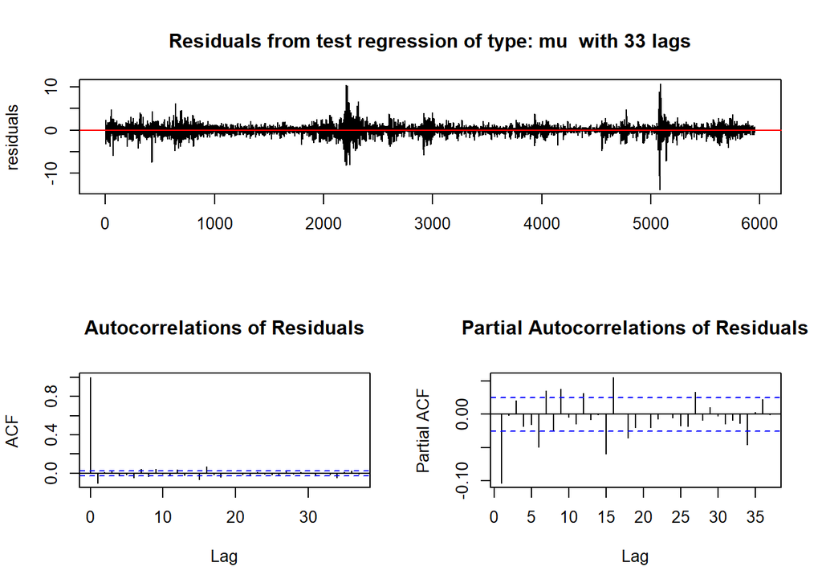

```r
plot(r_KPSS)
```

```r
r_diff_KPSS <- ur.kpss(r_diff, type = "mu", lags = "long")

summary(r_diff_KPSS)
```

```
##
## #######################
## # KPSS Unit Root Test #
## #######################
##
## Test is of type: mu with 33 lags.
##
## Value of test-statistic is: 0.0105
##
## Critical value for a significance level of:
##                 10pct  5pct 2.5pct  1pct
## critical values 0.347 0.463  0.574 0.739
```

## c) Plot the correlogram of r and r^2. What do they suggest about autocorrelation in the returns and in the squared returns on the Dow Jones Industrial Index? (2 marks)

The correlogram of the daily log returns shows that there’s only a weak dependence in the mean of the series, meaning its appropriate to assume a constant condition mean.

Conversely, The correlogram of the squared daily log returns indicates there substantial dependence in the volatility of the returns. This implies it might be an (G)ARCH process.

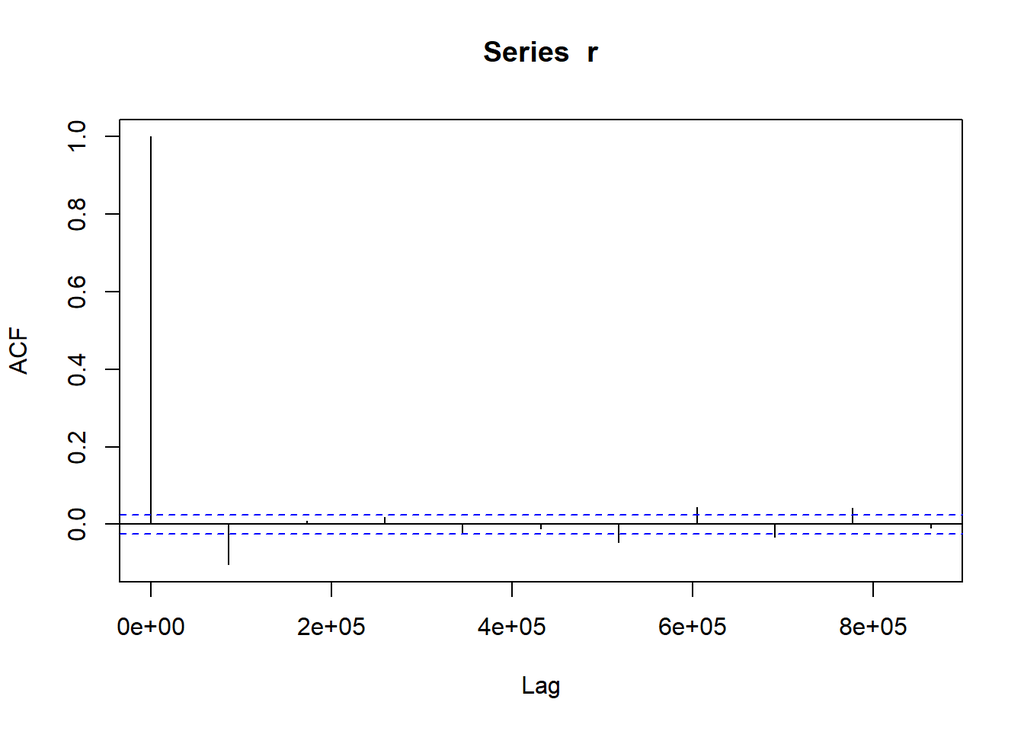

```r
s <- min(10, length(r)/5)

r_square <- r ^ 2

acf(r, lag.max = s)
```

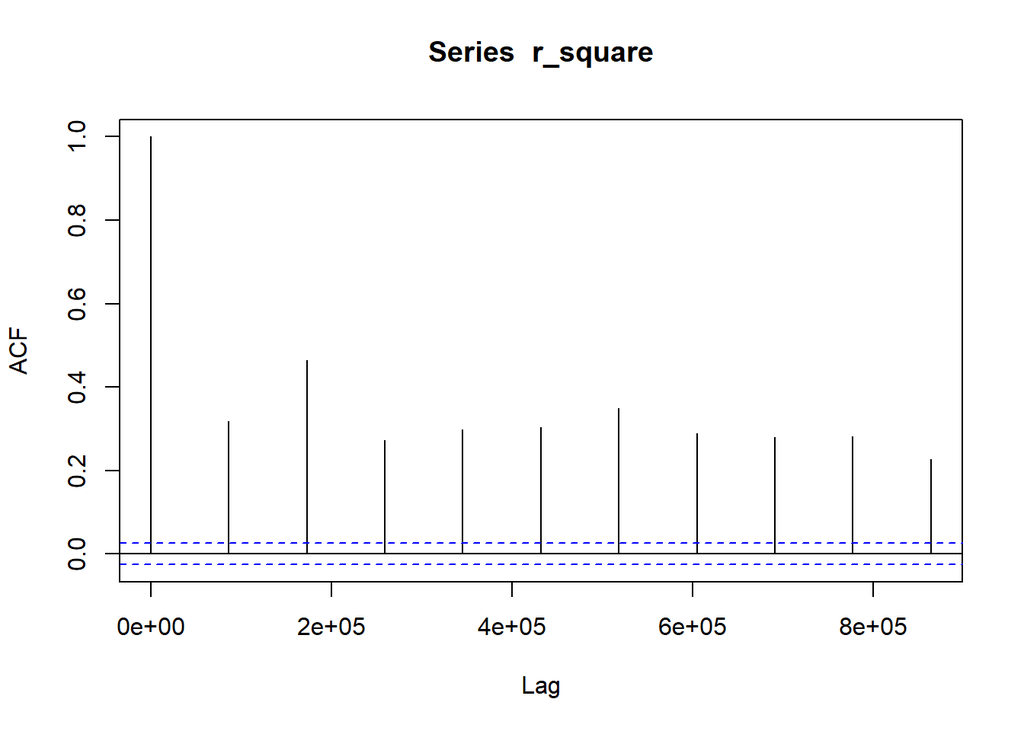

```r
acf(r_square, lag.max = s)
```

## d) Compute the daily standard deviation, variance, skewness, and kurtosis of r. Comment on the results. (3 marks)

These descriptive statistics tell us the following about the daily log returns of the Dow Jones Industrial Index:

- The standard deviation is 1.18, which means daily log returns are less tightly clustered around the mean than a series that is normally distributed as Gaussian distributions have a standard deviation of 1.
- The variance is 1.40, which tells us this series is more volatile than a Gaussian distributions, which have a variance of 1.
- The skewness is -0.36, which implies the series is quite significantly negatively skewed.
- The kurtosis is 12.61, which tells us that the thickness of the tails in the distribution is very high.

Overall, these descriptive statistics tell us it would be very difficult to describe this distribution as Gaussian.

```r
r_desc_stats <- bind_cols(sd(r), var(r), skewness(r),kurtosis(r)) %>%
  select( sd = 1, var = 2, skew = 3, kurt = 4)
print(r_desc_stats)
```

```
## # A tibble: 1 × 4
##      sd   var   skew  kurt
##   <dbl> <dbl>  <dbl> <dbl>
## 1  1.18  1.40 -0.369  12.6
```

## e) In general, the daily volatility of a stock is measured by the standard deviation of the daily stock price, and the annualized volatility is calculated by multiplying the daily volatility by the square root of 252. What is the annualized volatility of the Dow Jones Industrial Index? (2 marks)

The daily standard deviation of the Dow Jones Industrial Index is 1.18 according to this dataset. This implies an average annualised volatility of 18.80%.

```r
annualised_volatility <- r_desc_stats %>%
  select(sd) %>%
  mutate(ann_vol = sd * sqrt(252)) %>%
  select(ann_vol) %>%
  pull()

print(annualised_volatility)
```

```
## [1] 18.79777
```

## f) Estimate the GARCH(1,1) model for the returns of the Dow Jones Industrial Index as specified in the assignment printout.

## Consider your printout. Comment on the coefficients and on their significance based on robust standard errors. Briefly evaluate the weighted Ljung-Box tests, the weighted ARCH LM tests, the Nyblom stability tests, and the sign tests. For each group of these tests, state the null and alternative hypotheses, the statistical decision, and the conclusion. (8 marks)

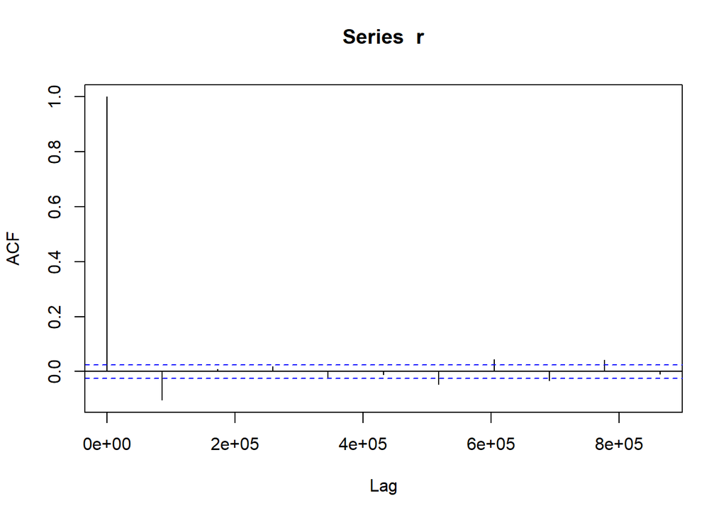

```r
acf(r, lag.max = s)
```

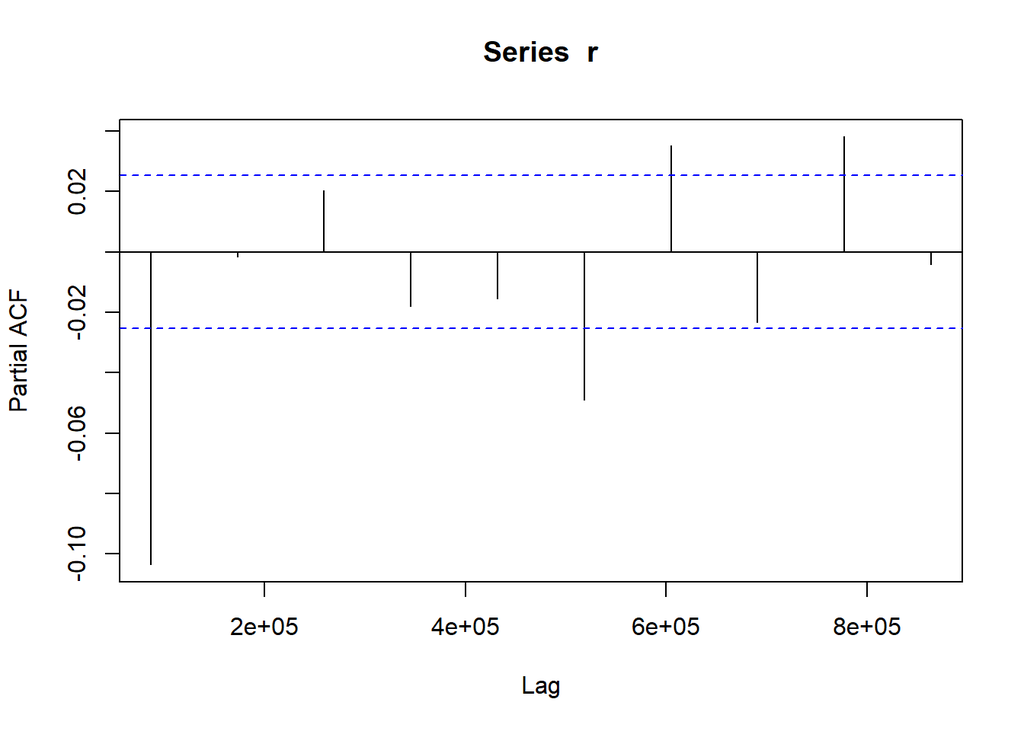

```r
pacf(r, lag.max = s)
```

```r
best.arima <- auto.arima(r, seasonal = FALSE, ic = "aicc",
approximation = FALSE, stepwise= FALSE, trace = TRUE)
```

```
##
##  ARIMA(0,0,0) with zero mean     : 18908.78
##  ARIMA(0,0,0) with non-zero mean : 18909.28
##  ARIMA(0,0,1) with zero mean     : 18847.66
##  ARIMA(0,0,1) with non-zero mean : 18847.78
##  ARIMA(0,0,2) with zero mean     : 18848.63
##  ARIMA(0,0,2) with non-zero mean : 18848.79
##  ARIMA(0,0,3) with zero mean     : 18849.1
##  ARIMA(0,0,3) with non-zero mean : 18849.33
##  ARIMA(0,0,4) with zero mean     : 18846.92
##  ARIMA(0,0,4) with non-zero mean : 18847.05
##  ARIMA(0,0,5) with zero mean     : 18847.1
##  ARIMA(0,0,5) with non-zero mean : 18847.16
##  ARIMA(1,0,0) with zero mean     : 18846.91
##  ARIMA(1,0,0) with non-zero mean : 18847.06
##  ARIMA(1,0,1) with zero mean     : 18848.91
##  ARIMA(1,0,1) with non-zero mean : 18849.06
##  ARIMA(1,0,2) with zero mean     : 18850.35
##  ARIMA(1,0,2) with non-zero mean : 18850.53
##  ARIMA(1,0,3) with zero mean     : 18843.32
##  ARIMA(1,0,3) with non-zero mean : 18843.53
##  ARIMA(1,0,4) with zero mean     : 18845.82
##  ARIMA(1,0,4) with non-zero mean : 18845.82
##  ARIMA(2,0,0) with zero mean     : 18848.91
##  ARIMA(2,0,0) with non-zero mean : 18849.05
##  ARIMA(2,0,1) with zero mean     : Inf
##  ARIMA(2,0,1) with non-zero mean : Inf
##  ARIMA(2,0,2) with zero mean     : 18848.95
##  ARIMA(2,0,2) with non-zero mean : 18849.2
##  ARIMA(2,0,3) with zero mean     : 18844.73
##  ARIMA(2,0,3) with non-zero mean : 18841.44
##  ARIMA(3,0,0) with zero mean     : 18848.34
##  ARIMA(3,0,0) with non-zero mean : 18848.56
##  ARIMA(3,0,1) with zero mean     : 18842.51
##  ARIMA(3,0,1) with non-zero mean : 18842.71
##  ARIMA(3,0,2) with zero mean     : 18839.87
##  ARIMA(3,0,2) with non-zero mean : 18840.11
##  ARIMA(4,0,0) with zero mean     : 18848.5
##  ARIMA(4,0,0) with non-zero mean : 18848.66
##  ARIMA(4,0,1) with zero mean     : 18847.18
##  ARIMA(4,0,1) with non-zero mean : 18847.18
##  ARIMA(5,0,0) with zero mean     : 18849.12
##  ARIMA(5,0,0) with non-zero mean : 18849.23
##
##
##
##  Best model: ARIMA(3,0,2) with zero mean
```

```r
summary(best.arima)
```

```
## Series: r
## ARIMA(3,0,2) with zero mean
##
## Coefficients:
##          ar1      ar2      ar3      ma1     ma2
##       0.2887  -0.8562  -0.0736  -0.3924  0.9044
## s.e.  0.0480   0.0549   0.0165   0.0459  0.0519
##
## sigma^2 = 1.385:  log likelihood = -9413.93
## AIC=18839.86   AICc=18839.87   BIC=18880.01
##
## Training set error measures:
##                      ME     RMSE       MAE MPE MAPE      MASE          ACF1
## Training set 0.02037915 1.176371 0.7777611 NaN  Inf 0.9981901 -0.0004899758
```

```r
coeftest(best.arima, df = best.arima$nobs - length(best.arima$coef))
```

```
##
## t test of coefficients:
##
##      Estimate Std. Error  t value  Pr(>|t|)
## ar1  0.288726   0.048046   6.0093 1.973e-09 ***
## ar2 -0.856199   0.054922 -15.5895 < 2.2e-16 ***
## ar3 -0.073573   0.016537  -4.4491 8.779e-06 ***
## ma1 -0.392380   0.045884  -8.5516 < 2.2e-16 ***
## ma2  0.904444   0.051889  17.4304 < 2.2e-16 ***
## ---
## Signif. codes:  0 '***' 0.001 '**' 0.01 '*' 0.05 '.' 0.1 ' ' 1
```

```r
k <- length(best.arima$coef)

Box.test(best.arima$residuals, type = "Ljung-Box", lag = 10, fitdf = k)
```

```
##
##  Box-Ljung test
##
## data:  best.arima$residuals
## X-squared = 34.388, df = 5, p-value = 1.993e-06
```

The code below estimates a GARCH(1,1) model where the condition mean equation is equal to white noise with a constant. We interpret the output as follows:

- For the estimated model coefficients:
  - This section assesses the significance of all the terms in the mean and variance equation using both regular standard errors based on the Maximum Likelihood (ML) and normal distribution, as well as robust standard errors based on the Quasi Maximum Likelihood.
  - The null hypothesis for these tests on the model coefficient is that their value is equal to zero, whereas the alternate hypothesis is that they are not equal to zero
  - Regardles of if we use normal or robust standard errors, all of the terms in this GARCH(1,1) model are significant as all their p-values are effectively zero.
  - Therefore, there is no immediate reason to consider changing any of the terms in the mean or variance equation as they are all statistically different from zero. This support the specification of a GARCH(1,1) model for the daily log returns of the Dow Jones Industrial Index.
- For the Weighted LB tests:
  - The null hypothesis for these tests is that there is no autocorrelation of (i) order 1, (ii) orders 1-2 and (iii) orders 1-5 in the standardised residuals and the standardised squared residuals. The alternate hypothesis is that there is autocorrelation for any given order of the standardised residuals and standardised squared residuals.
  - For the standardised residuals, we are not able to maintain the null hypothesis for the test on autocorrelation of orders (i) order 1 and (ii) orders 1-2 as their p-values (0.02 and 0.03 respectively) are both smaller than 0.05. This means we must reject the null hypothesis and conclude there is autocorrelation in the standardised residuals of order 1 and orders 1-2. However, we are able to maintain the null hypothesis for the test for orders 1-5, as the p-value is greater than 0.05 (0.08). However, we cannot maintain this conclusion at the 10% significance level.
  - However, for the three tests on autocorrelation in the standardised squared residuals, we are able to maintain the null hypothesis that there is no autocorrelation in the standardised squared residuals of (i) order 1, (ii) orders 1-2 and (iii) orders 1-5 in the standardised squared residuals. This is because all of their p-values (0.5, 0.48 and 0.45) are greater than 0.05. In fact, we could even maintain this conclusion at the 10% significance level.
  - The evidence of autocorrelation in the standardised residuals of order 1 and orders 1-2 does not support the GARCH(1,1) model specification.
- For the Weighted ARCH LM tests:
  - The null hypothesis is that there are no ARCH effects left in the residuals. The alternate hypothesis is that there are ARCH effects left in the residuals.
  - All of the p-values (0.50, 0.48 and 0.45) are sufficiently large to maintain the null hypothesis that there are no ARCH effects remaining in the standardised residuals at lags 2, 5 and 7.
  - As these tests suggest there are no ARCH effects remaining in the standardised residuals, this outcome supports the GARCH(1,1) model specification.
- For the Nyblom stability test:
  - The null hypothesis for the Nyblom stability test is that the parameters given for the chosen model are stable over time. The alternate hypothesis is that they are unstable.
  - When evaluating the Nyblom stability test you need to consider the joint and individual statistics.
  - The joint statistic is 2.66, which is above the joint statistic 1% critical value of 1.6. Therefore, there we reject then null hypothesis for the model as a whole at the 1% significance level.
  - This is also the case for the individual tests, where all test statistics for each parameter are greater than the 1% critical value of 0.75. Therefore, we are also able to reject the null hypothesis for each parameter at the 1% significance level.
  - Therefore, there is significant evidence of parameter instability both overall and at the individual parameter level because every Nyblom stability test rejects the null hypothesis that there is no instability in the parameters.This does not support the GARCH(1,1) model specification.
- For the sign tests:
  - The null hypothesis is that negative and positive returns do not have different impact on future volatility. The alternate hypothesis is that negative and positive returns have different impact on future volatility. This test is conducted joint, and separately to determine if the effect is negatively or positively biased.
  - Jointly, the p-value is sufficiently close to zero to reject the null hypothesis that negative and positive returns have do not have different impacts on volatility. This is also the case for the test specifically for positive sign bias: we reject the null hypothesis. However, this is not the case for the negative sign bias test, and we retain the null hypothesis in this instance that there is no negative.
  - Overall, these tests detect some leverage effects, both jointly and specifically for positive sign bias.This does not support the GARCH(1,1) model specification.

```r
spec_v1 = ugarchspec(mean.model = list(armaOrder = c(0,0), include.mean = TRUE),
                     variance.model = list(model = "sGARCH", garchOrder = c(1,1)),
                     distribution.model = "norm")

estimate_v1 <- ugarchfit(spec = spec_v1, data = r)

print(estimate_v1)
```

```
##
## *---------------------------------*
## *          GARCH Model Fit        *
## *---------------------------------*
##
## Conditional Variance Dynamics
## -----------------------------------
## GARCH Model  : sGARCH(1,1)
## Mean Model   : ARFIMA(0,0,0)
## Distribution : norm
##
## Optimal Parameters
## ------------------------------------
##         Estimate  Std. Error  t value Pr(>|t|)
## mu      0.058545    0.010064   5.8171        0
## omega   0.022092    0.002821   7.8321        0
## alpha1  0.125958    0.009458  13.3178        0
## beta1   0.857473    0.009673  88.6434        0
##
## Robust Standard Errors:
##         Estimate  Std. Error  t value Pr(>|t|)
## mu      0.058545    0.009884   5.9230        0
## omega   0.022092    0.004204   5.2555        0
## alpha1  0.125958    0.014919   8.4428        0
## beta1   0.857473    0.014794  57.9608        0
##
## LogLikelihood : -7972.597
##
## Information Criteria
## ------------------------------------
##
## Akaike       2.6799
## Bayes        2.6844
## Shibata      2.6799
## Hannan-Quinn 2.6814
##
## Weighted Ljung-Box Test on Standardized Residuals
## ------------------------------------
##                         statistic p-value
## Lag[1]                      5.187 0.02275
```

[output cut: 37 more lines]

```
## Negative Sign Bias  0.9472 3.436e-01
## Positive Sign Bias  2.0799 3.758e-02  **
## Joint Effect       33.4452 2.594e-07 ***
##
##
## Adjusted Pearson Goodness-of-Fit Test:
## ------------------------------------
##   group statistic p-value(g-1)
## 1    20     170.1    2.674e-26
## 2    30     191.5    7.374e-26
## 3    40     205.5    1.713e-24
## 4    50     226.1    1.450e-24
##
##
## Elapsed time : 0.213165
```

## g) Estimate the TGARCH(1,1) model for the returns of the Dow Jones Industrial as specified in the assignment printout.

Do the results imply that negative innovations have greater impact on the conditional variance of the Dow Jones returns than positive innovations? Which model do you prefer, GARCH(1,1) or TGARCH(1,1)? Explain your answers. (4 marks)

Do the results imply the negative innovations have greater impact on the condition variance of the Dow Jones returns than positive innovations?

- Yes, there is evidence that negative innovations have greater impact on the condition variance of the Dow Jones returns than positive innovations.
- This is because the parameter eta11 is significantly positive, with a value of 0.90 and a p-value close to zero. In TGARCH models, a significantly positive eta11-hat value implies that negative shocks have greater effect on expected volatility than positive shocks.

Which model do you prefer, GARCH(1,1) or TGARCH(1,1)?

```r
spec_v2 = ugarchspec(mean.model = list(armaOrder = c(0,0), include.mean = TRUE),
                     variance.model = list(model = "fGARCH", submodel = "TGARCH",
                                           garchOrder = c(1,1)),
                     distribution.model = "norm")

estimate_v2 <- ugarchfit(spec = spec_v2, data = r)

print(estimate_v2)
```

```
##
## *---------------------------------*
## *          GARCH Model Fit        *
## *---------------------------------*
##
## Conditional Variance Dynamics
## -----------------------------------
## GARCH Model  : fGARCH(1,1)
## fGARCH Sub-Model : TGARCH
## Mean Model   : ARFIMA(0,0,0)
## Distribution : norm
##
## Optimal Parameters
## ------------------------------------
##         Estimate  Std. Error  t value Pr(>|t|)
## mu      0.015987    0.009618   1.6621 0.096498
## omega   0.027153    0.002523  10.7619 0.000000
## alpha1  0.093021    0.007325  12.6999 0.000000
## beta1   0.901521    0.007118 126.6579 0.000000
## eta11   0.902888    0.069842  12.9275 0.000000
##
## Robust Standard Errors:
##         Estimate  Std. Error  t value Pr(>|t|)
## mu      0.015987    0.009760   1.6380  0.10143
## omega   0.027153    0.004966   5.4683  0.00000
## alpha1  0.093021    0.013946   6.6699  0.00000
## beta1   0.901521    0.013986  64.4598  0.00000
## eta11   0.902888    0.127875   7.0607  0.00000
##
## LogLikelihood : -7839.096
##
## Information Criteria
## ------------------------------------
##
## Akaike       2.6353
## Bayes        2.6410
## Shibata      2.6353
## Hannan-Quinn 2.6373
##
## Weighted Ljung-Box Test on Standardized Residuals
```

[output cut: 41 more lines]

```
## Negative Sign Bias   1.892 0.05849   *
## Positive Sign Bias   1.098 0.27246
## Joint Effect         8.741 0.03294  **
##
##
## Adjusted Pearson Goodness-of-Fit Test:
## ------------------------------------
##   group statistic p-value(g-1)
## 1    20     121.7    5.266e-17
## 2    30     144.1    3.231e-17
## 3    40     162.6    5.058e-17
## 4    50     182.2    3.287e-17
##
##
## Elapsed time : 0.4623759
```